# COVID_Apply_ML_Models-05152020

**Objective of this notebook is to study COVID-19 outbreak with the help of some basic visualizations techniques. Comparison of countries spread of COVID-19 in the World. Perform predictions and Time Series forecasting in order to study the impact and spread of the COVID-19 in comming days.**

### Kaggle Data Source:

https://www.kaggle.com/sudalairajkumar/novel-corona-virus-2019-dataset

```python
import warnings
warnings.filterwarnings('ignore')
import pandas as pd
import matplotlib.pyplot as plt
import seaborn as sns
import numpy as np
import datetime as dt
from datetime import timedelta

from sklearn.model_selection import GridSearchCV
from sklearn.preprocessing import StandardScaler
from sklearn.cluster import KMeans
from sklearn.metrics import silhouette_score,silhouette_samples
from sklearn.linear_model import LinearRegression,Ridge,Lasso,LogisticRegression
from sklearn.svm import SVR
from sklearn.metrics import mean_squared_error,r2_score
import statsmodels.api as sm
from statsmodels.tsa.api import Holt,SimpleExpSmoothing,ExponentialSmoothing

from sklearn.preprocessing import PolynomialFeatures
from statsmodels.tsa.stattools import adfuller
from statsmodels.tsa.ar_model import AR
from statsmodels.tsa.arima_model import ARIMA
from statsmodels.graphics.tsaplots import plot_acf,plot_pacf
std=StandardScaler()
#pd.set_option('display.float_format', lambda x: '%.6f' % x)

#for evaluation of classification models
from sklearn.metrics import classification_report, f1_score, accuracy_score, confusion_matrix
from sklearn.model_selection import StratifiedKFold, cross_val_score, train_test_split, GridSearchCV
from sklearn import metrics
from sklearn.metrics import roc_curve, auc, roc_auc_score

#for evaluation of regression models (machine learning)
from sklearn.metrics import mean_squared_error
from sklearn.metrics import explained_variance_score
```

```python
from pathlib import Path, PureWindowsPath
import os

# Get the path of current working directory and add COVID directory path to it
path = os.getcwd()
covid_dir = "C:\\Users\\Vejendla\\Desktop\\CIS-732\\novel-corona-virus-2019-dataset\\"

# Convert path to Windows format
#path_on_windows = PureWindowsPath(covid_dir)
#print(path_on_windows)
filenames = os.listdir(covid_dir)
print("Number of articles retrieved from novel-corona-virus-2019-dataset:", len(filenames))
```

```
Number of articles retrieved from novel-corona-virus-2019-dataset: 8
```

```python
#Reading the cumulative cases dataset
covid = pd.read_csv(r'C:\Users\Vejendla\Desktop\CIS-732\novel-corona-virus-2019-dataset\covid_19_data.csv')
#Viewing the dataset
covid.head()
```

|  | SNo | ObservationDate | Province/State | Country/Region | Last Update | Confirmed | Deaths | Recovered |
| --- | --- | --- | --- | --- | --- | --- | --- | --- |
| 0 | 1 | 01/22/2020 | Anhui | Mainland China | 1/22/2020 17:00 | 1.0 | 0.0 | 0.0 |
| 1 | 2 | 01/22/2020 | Beijing | Mainland China | 1/22/2020 17:00 | 14.0 | 0.0 | 0.0 |
| 2 | 3 | 01/22/2020 | Chongqing | Mainland China | 1/22/2020 17:00 | 6.0 | 0.0 | 0.0 |
| 3 | 4 | 01/22/2020 | Fujian | Mainland China | 1/22/2020 17:00 | 1.0 | 0.0 | 0.0 |
| 4 | 5 | 01/22/2020 | Gansu | Mainland China | 1/22/2020 17:00 | 0.0 | 0.0 | 0.0 |

```python
print("Size/Shape of the dataset: ",covid.shape)
print("Checking for null values:\n",covid.isnull().sum())
print("Checking Data-type of each column:\n",covid.dtypes)
```

```
Size/Shape of the dataset:  (24451, 8)
Checking for null values:
 SNo                    0
ObservationDate        0
Province/State     12745
Country/Region         0
Last Update            0
Confirmed              0
Deaths                 0
Recovered              0
dtype: int64
Checking Data-type of each column:
 SNo                  int64
ObservationDate     object
Province/State      object
Country/Region      object
Last Update         object
Confirmed          float64
Deaths             float64
Recovered          float64
dtype: object
```

```python
#Dropping column as SNo is of no use, and "Province/State" contains too many missing values
covid.drop(["SNo"],1,inplace=True)
```

```python
#Converting "Observation Date" into Datetime format
covid["ObservationDate"]=pd.to_datetime(covid["ObservationDate"])
```

```python
#Grouping different types of cases as per the date
datewise=covid.groupby(["ObservationDate"]).agg({"Confirmed":'sum',"Recovered":'sum',"Deaths":'sum'})
datewise["Days Since"]=datewise.index-datewise.index.min()
```

```python
print("Basic Information")
print("Totol number of countries with Disease Spread: ",len(covid["Country/Region"].unique()))
print("Total number of Confirmed Cases around the World: ",datewise["Confirmed"].iloc[-1])
print("Total number of Recovered Cases around the World: ",datewise["Recovered"].iloc[-1])
print("Total number of Deaths Cases around the World: ",datewise["Deaths"].iloc[-1])
print("Total number of Active Cases around the World: ",(datewise["Confirmed"].iloc[-1]-datewise["Recovered"].iloc[-1]-datewise["Deaths"].iloc[-1]))
print("Total number of Closed Cases around the World: ",datewise["Recovered"].iloc[-1]+datewise["Deaths"].iloc[-1])
print("Approximate number of Confirmed Cases per Day around the World: ",np.round(datewise["Confirmed"].iloc[-1]/datewise.shape[0]))
print("Approximate number of Recovered Cases per Day around the World: ",np.round(datewise["Recovered"].iloc[-1]/datewise.shape[0]))
print("Approximate number of Death Cases per Day around the World: ",np.round(datewise["Deaths"].iloc[-1]/datewise.shape[0]))
print("Approximate number of Confirmed Cases per hour around the World: ",np.round(datewise["Confirmed"].iloc[-1]/((datewise.shape[0])*24)))
print("Approximate number of Recovered Cases per hour around the World: ",np.round(datewise["Recovered"].iloc[-1]/((datewise.shape[0])*24)))
print("Approximate number of Death Cases per hour around the World: ",np.round(datewise["Deaths"].iloc[-1]/((datewise.shape[0])*24)))
print("Number of Confirmed Cases in last 24 hours: ",datewise["Confirmed"].iloc[-1]-datewise["Confirmed"].iloc[-2])
print("Number of Confirmed Cases in last 24 hours: ",datewise["Recovered"].iloc[-1]-datewise["Recovered"].iloc[-2])
print("Number of Confirmed Cases in last 24 hours: ",datewise["Deaths"].iloc[-1]-datewise["Deaths"].iloc[-2])
```

```
Basic Information
Totol number of countries with Disease Spread:  223
Total number of Confirmed Cases around the World:  4347018.0
Total number of Recovered Cases around the World:  1548547.0
Total number of Deaths Cases around the World:  297197.0
Total number of Active Cases around the World:  2501274.0
Total number of Closed Cases around the World:  1845744.0
Approximate number of Confirmed Cases per Day around the World:  38469.0
Approximate number of Recovered Cases per Day around the World:  13704.0
Approximate number of Death Cases per Day around the World:  2630.0
Approximate number of Confirmed Cases per hour around the World:  1603.0
Approximate number of Recovered Cases per hour around the World:  571.0
Approximate number of Death Cases per hour around the World:  110.0
Number of Confirmed Cases in last 24 hours:  85063.0
Number of Confirmed Cases in last 24 hours:  55133.0
Number of Confirmed Cases in last 24 hours:  5233.0
```

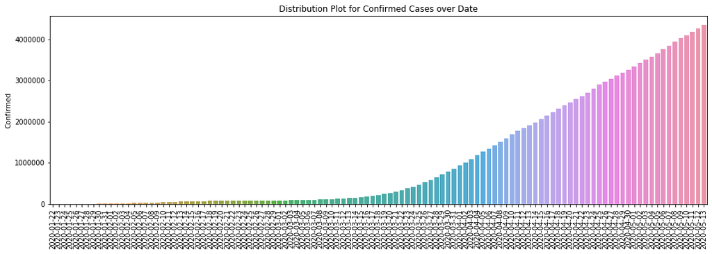

```python
plt.figure(figsize=(17,5))
sns.barplot(x=datewise.index.date, y=datewise["Confirmed"])
#sns.barplot(x=datewise.index.date, y=datewise["Deaths"])
plt.title("Distribution Plot for Confirmed Cases over Date")
plt.xticks(rotation=90)
```

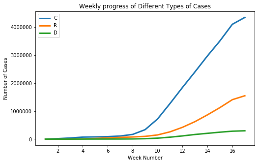

```python
datewise["WeekOfYear"]=datewise.index.weekofyear

week_num=[]
weekwise_confirmed=[]
weekwise_recovered=[]
weekwise_deaths=[]
w=1
for i in list(datewise["WeekOfYear"].unique()):
    weekwise_confirmed.append(datewise[datewise["WeekOfYear"]==i]["Confirmed"].iloc[-1])
    weekwise_recovered.append(datewise[datewise["WeekOfYear"]==i]["Recovered"].iloc[-1])
    weekwise_deaths.append(datewise[datewise["WeekOfYear"]==i]["Deaths"].iloc[-1])
    week_num.append(w)
    w=w+1

plt.figure(figsize=(8,5))
plt.plot(week_num,weekwise_confirmed,linewidth=3)
plt.plot(week_num,weekwise_recovered,linewidth=3)
plt.plot(week_num,weekwise_deaths,linewidth=3)
plt.ylabel("Number of Cases")
plt.xlabel("Week Number")
plt.title("Weekly progress of Different Types of Cases")
plt.legend('CRD')
```

### Update as of 15th May 2020:

[output not shown]

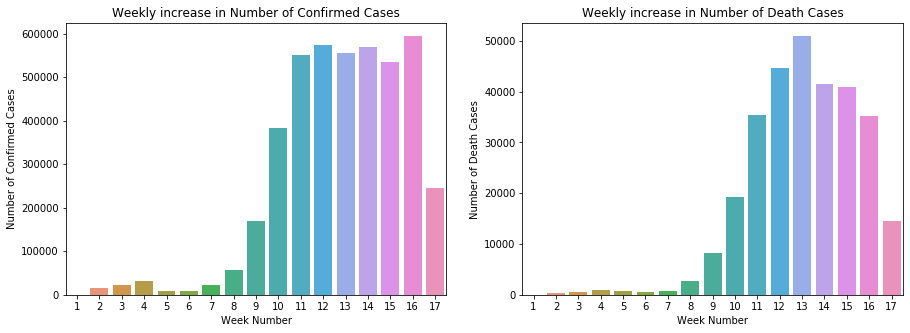

```python
fig, (ax1,ax2) = plt.subplots(1, 2,figsize=(15,5))
sns.barplot(x=week_num,y=pd.Series(weekwise_confirmed).diff().fillna(0),ax=ax1)
sns.barplot(x=week_num,y=pd.Series(weekwise_deaths).diff().fillna(0),ax=ax2)
ax1.set_xlabel("Week Number")
ax2.set_xlabel("Week Number")
ax1.set_ylabel("Number of Confirmed Cases")
ax2.set_ylabel("Number of Death Cases")
ax1.set_title("Weekly increase in Number of Confirmed Cases")
ax2.set_title("Weekly increase in Number of Death Cases")
```

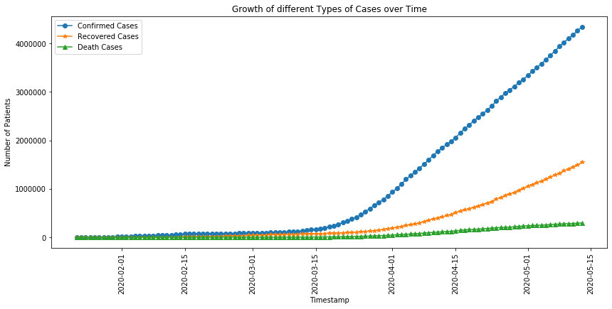

```python
plt.figure(figsize=(14,6))
plt.plot(datewise["Confirmed"],marker="o",label="Confirmed Cases")
plt.plot(datewise["Recovered"],marker="*",label="Recovered Cases")
plt.plot(datewise["Deaths"],marker="^",label="Death Cases")
plt.ylabel("Number of Patients")
plt.xlabel("Timestamp")
plt.xticks(rotation=90)
plt.title("Growth of different Types of Cases over Time")
plt.legend()
```

```
Average Mortality Rate 4.491230943263976
Median Mortality Rate 4.063466952050811
Average Recovery Rate 26.245328054684137
Median Recovery Rate 25.76765351874094
```

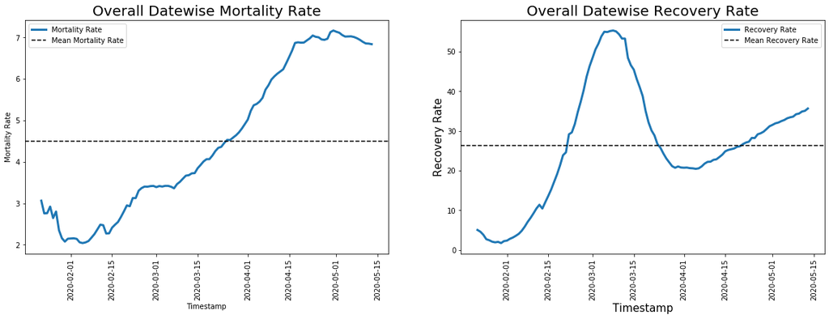

```python
#Calculating the Mortality Rate and Recovery Rate
datewise["Mortality Rate"]=(datewise["Deaths"]/datewise["Confirmed"])*100
datewise["Recovery Rate"]=(datewise["Recovered"]/datewise["Confirmed"])*100
datewise["Active Cases"]=datewise["Confirmed"]-datewise["Recovered"]-datewise["Deaths"]
datewise["Closed Cases"]=datewise["Recovered"]+datewise["Deaths"]

#Plotting Mortality and Recovery Rate
fig, (ax1, ax2) = plt.subplots(1, 2,figsize=(20,6))
ax1.plot(datewise["Mortality Rate"],label='Mortality Rate',linewidth=3)
ax1.axhline(datewise["Mortality Rate"].mean(),linestyle='--',color='black',label="Mean Mortality Rate")
ax1.set_ylabel("Mortality Rate")
ax1.set_xlabel("Timestamp")
ax1.set_title("Overall Datewise Mortality Rate", size=20)
ax1.legend()
for tick in ax1.get_xticklabels():
    tick.set_rotation(90)
ax2.plot(datewise["Recovery Rate"],label="Recovery Rate",linewidth=3)
ax2.axhline(datewise["Recovery Rate"].mean(),linestyle='--',color='black',label="Mean Recovery Rate")
ax2.set_ylabel("Recovery Rate")
ax2.set_xlabel("Timestamp")
ax2.set_title("Overall Datewise Recovery Rate", size=20)
ax2.legend()
for tick in ax2.get_xticklabels():
    tick.set_rotation(90)

print("Average Mortality Rate",datewise["Mortality Rate"].mean())
print("Median Mortality Rate",datewise["Mortality Rate"].median())
print("Average Recovery Rate",datewise["Recovery Rate"].mean())
print("Median Recovery Rate",datewise["Recovery Rate"].median())
```

- Mortality rate = (Number of Death Cases / Number of Confirmed Cases) x 100
- Recovery Rate= (Number of Recoverd Cases / Number of Confirmed Cases) x 100
- Mortality rate increment is pretty significant That's a conclusive evidence why number of Closed Cases and Death Cases are more.
- Recovery Rate has started to pick up again which is a good sign, another supportive reason to why number of Closed Cases are increasing

```
Average increase in number of Confirmed Cases every day:  38464.0
Average increase in number of Recovered Cases every day:  13704.0
Average increase in number of Deaths Cases every day:  2630.0
```

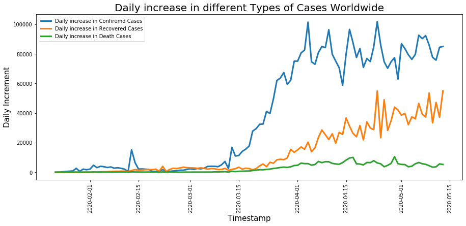

```python
print("Average increase in number of Confirmed Cases every day: ",np.round(datewise["Confirmed"].diff().fillna(0).mean()))
print("Average increase in number of Recovered Cases every day: ",np.round(datewise["Recovered"].diff().fillna(0).mean()))
print("Average increase in number of Deaths Cases every day: ",np.round(datewise["Deaths"].diff().fillna(0).mean()))

plt.figure(figsize=(15,6))
plt.plot(datewise["Confirmed"].diff().fillna(0),label="Daily increase in Confiremd Cases",linewidth=3)
plt.plot(datewise["Recovered"].diff().fillna(0),label="Daily increase in Recovered Cases",linewidth=3)
plt.plot(datewise["Deaths"].diff().fillna(0),label="Daily increase in Death Cases",linewidth=3)
plt.xlabel("Timestamp",  size = 15)
plt.ylabel("Daily Increment",  size = 15)
plt.title("Daily increase in different Types of Cases Worldwide",  size = 20)
plt.xticks(rotation=90)
plt.legend()
```

# Countrywise Analysis

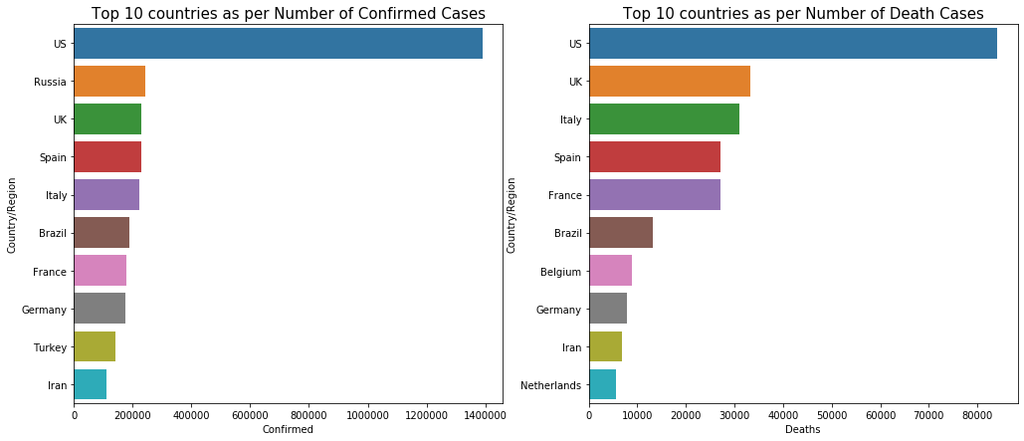

```python
#Calculating countrywise Moratality and Recovery Rate
countrywise=covid[covid["ObservationDate"]==covid["ObservationDate"].max()].groupby(["Country/Region"]).agg({"Confirmed":'sum',"Recovered":'sum',"Deaths":'sum'}).sort_values(["Confirmed"],ascending=False)
countrywise["Mortality"]=(countrywise["Deaths"]/countrywise["Confirmed"])*100
countrywise["Recovery"]=(countrywise["Recovered"]/countrywise["Confirmed"])*100

fig, (ax1, ax2) = plt.subplots(1, 2,figsize=(17,7))
top_10_confirmed=countrywise.sort_values(["Confirmed"],ascending=False).head(10)
top_10_deaths=countrywise.sort_values(["Deaths"],ascending=False).head(10)

sns.barplot(x=top_10_confirmed["Confirmed"],y=top_10_confirmed.index,ax=ax1)
ax1.set_title("Top 10 countries as per Number of Confirmed Cases",  size = 15);

sns.barplot(x=top_10_deaths["Deaths"],y=top_10_deaths.index,ax=ax2)
ax2.set_title("Top 10 countries as per Number of Death Cases",  size = 15);
```

# Journey of different Countries in COVID-19

When we see daily news reports on COVID-19 it's really hard to interpret what's actually happening, since the numbers are changing so rapidly but that's something expected from Exponential growth. Since almost all the pandemics tend to grow exponentially it's really hard to understand for someone from a non-mathematical or non-statistical background.

We are more concerned about how we are doing and where we are heading in this pandemic rather than just looking at those exponentially growing numbers. The growth won't be exponentially forever, at some point of time the curve will become flat because probably all the people on the planet are infected or we human have been able to control the disease. When we are in the middle of the exponential growth it's almost impossible to tell where are we heading.

Here, I am trying to show how we can interpret the exponential growth which is the common trend among all the countries

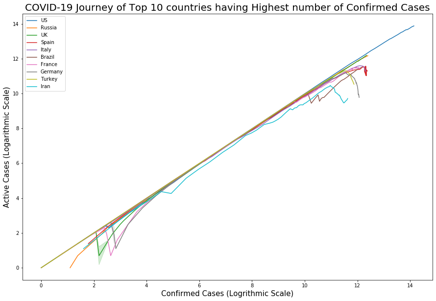

```python
grouped_country=covid.groupby(["Country/Region","ObservationDate"]).agg({"Confirmed":'sum',"Recovered":'sum',"Deaths":'sum'})
grouped_country["Active Cases"]=grouped_country["Confirmed"]-grouped_country["Recovered"]-grouped_country["Deaths"]
grouped_country["log_confirmed"]=np.log(grouped_country["Confirmed"])
grouped_country["log_active"]=np.log(grouped_country["Active Cases"])

plt.figure(figsize=(15,10))
for country in countrywise.head(10).index:
    sns.lineplot(x=grouped_country.ix[country]["log_confirmed"],y=grouped_country.ix[country]["log_active"],label=country)
plt.xlabel("Confirmed Cases (Logrithmic Scale)",  size = 15)
plt.ylabel("Active Cases (Logarithmic Scale)",  size = 15)
plt.title("COVID-19 Journey of Top 10 countries having Highest number of Confirmed Cases",  size = 20)
```

### update as of 26/4:

It's pretty evident that the disease is spreading in same manner everywhere, but if particular country is following pandemic controlling practices rigrously the results are evident in the graph.

Most of the countries will follow the same trajectory as that USA, which is "Uncontrolled Exponential Growth"

Germany and Iran are seems to be heading towards that dip, showing the pandemic control practices are woking in favour.

### Update as of 5/5:

China is not part of top 10 hits anymore, perhaps of right medical guidelines they took, worked in their favour.

Italy seem to going down with confirmed cases in recent days, which is a good news.

### Update as of 5/15:

USA, UK , Russia are still going up, which means the situations are still uncontrolled, pandemic is exponentially growing.

# Clustering of Countries

### Cluster Using KMeans

```python
X=countrywise[["Confirmed","Deaths"]]
X=std.fit_transform(X)

wcss=[]
sil=[]
for i in range(2,11):
    clf=KMeans(n_clusters=i,init='k-means++',random_state=42)
    clf.fit(X)
    labels=clf.labels_
    centroids=clf.cluster_centers_
    sil.append(silhouette_score(X, labels, metric='euclidean'))
    wcss.append(clf.inertia_)
```

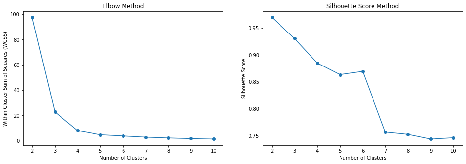

```python
fig, (ax1, ax2) = plt.subplots(1, 2,figsize=(16,5))
x=np.arange(2,11)
ax1.plot(x,wcss,marker='o')
ax1.set_xlabel("Number of Clusters")
ax1.set_ylabel("Within Cluster Sum of Squares (WCSS)")
ax1.set_title("Elbow Method")
x=np.arange(2,11)
ax2.plot(x,sil,marker='o')
ax2.set_xlabel("Number of Clusters")
ax2.set_ylabel("Silhouette Score")
ax2.set_title("Silhouette Score Method")
```

```python
clf_final=KMeans(n_clusters=4,init='k-means++',random_state=42)
clf_final.fit(X)
```

```
KMeans(algorithm='auto', copy_x=True, init='k-means++', max_iter=300,
       n_clusters=4, n_init=10, n_jobs=None, precompute_distances='auto',
       random_state=42, tol=0.0001, verbose=0)
```

```python
countrywise["Clusters"]=clf_final.predict(X)
```

### Summary of Clusters

```python
#showing 5 rows of each cluster
pd.concat([countrywise[countrywise["Clusters"]==1],countrywise[countrywise["Clusters"]==2],countrywise[countrywise["Clusters"]==3],countrywise[countrywise["Clusters"]==0].head(5)])
```

| Country/Region | Confirmed | Recovered | Deaths | Mortality | Recovery | Clusters |
| --- | --- | --- | --- | --- | --- | --- |
| US | 1390406.0 | 243430.0 | 84119.0 | 6.049960 | 17.507836 | 1 |
| UK | 230985.0 | 1032.0 | 33264.0 | 14.400935 | 0.446782 | 2 |
| Spain | 228691.0 | 140823.0 | 27104.0 | 11.851800 | 61.577850 | 2 |
| Italy | 222104.0 | 112541.0 | 31106.0 | 14.005151 | 50.670407 | 2 |
| France | 178184.0 | 58786.0 | 27077.0 | 15.196089 | 32.991739 | 2 |
| Russia | 242271.0 | 48003.0 | 2212.0 | 0.913027 | 19.813762 | 3 |
| Brazil | 190137.0 | 78424.0 | 13240.0 | 6.963400 | 41.246049 | 3 |
| Germany | 174098.0 | 148700.0 | 7861.0 | 4.515273 | 85.411665 | 3 |
| Turkey | 143114.0 | 101715.0 | 3952.0 | 2.761435 | 71.072711 | 3 |
| Iran | 112725.0 | 89428.0 | 6783.0 | 6.017299 | 79.332890 | 3 |
| Mainland China | 82929.0 | 78195.0 | 4633.0 | 5.586707 | 94.291502 | 3 |
| India | 78055.0 | 26400.0 | 2551.0 | 3.268208 | 33.822305 | 3 |
| Peru | 76306.0 | 24324.0 | 2169.0 | 2.842503 | 31.876917 | 3 |
| Canada | 73568.0 | 35177.0 | 5425.0 | 7.374130 | 47.815626 | 3 |
| Belgium | 53981.0 | 13937.0 | 8843.0 | 16.381690 | 25.818343 | 3 |
| Netherlands | 43410.0 | 157.0 | 5581.0 | 12.856485 | 0.361668 | 3 |
| Saudi Arabia | 44830.0 | 17622.0 | 273.0 | 0.608967 | 39.308499 | 0 |
| Mexico | 40186.0 | 26990.0 | 4220.0 | 10.501170 | 67.162693 | 0 |
| Pakistan | 35298.0 | 8899.0 | 761.0 | 2.155930 | 25.211060 | 0 |
| Chile | 34381.0 | 14865.0 | 346.0 | 1.006370 | 43.236090 | 0 |
| Ecuador | 30486.0 | 3433.0 | 2334.0 | 7.655973 | 11.260907 | 0 |

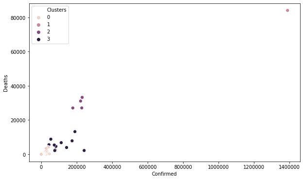

```python
plt.figure(figsize=(10,6))
sns.scatterplot(x=countrywise["Confirmed"],y=countrywise["Deaths"],hue=countrywise["Clusters"],s=50);
```

Each cluster is distinctly visible in scatterplot below.

- Cluster 3 is set of countries which are moderately or very less affected
- Cluster 2 is set of countries which are severly affected
- Cluster 1 is set of countries which are worsly affected.
- cluster 0 is set of countries that mildly effected

### Elaborate the cluster plot (in 3D) on Logarithmic Scale

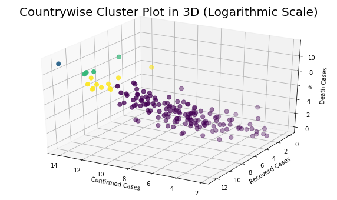

```python
fig = plt.figure(figsize=(10,6))
ax = fig.add_subplot(111, projection='3d')
ax.scatter(np.log(countrywise["Confirmed"]),np.log(countrywise["Recovered"]),np.log(countrywise["Deaths"]), c=countrywise["Clusters"],
           marker='o',s=50)
ax.view_init(azim=120)
ax.set_xlabel('Confirmed Cases')
ax.set_ylabel('Recoverd Cases')
ax.set_zlabel('Death Cases')
plt.title("Countrywise Cluster Plot in 3D (Logarithmic Scale)", size=20)
plt.show()
```

# Prediction using Machine Learning Models

### Split train and test data to be before and after 1st May 2020 respectively

```python
datewise["Days Since"]=datewise.index-datewise.index[0]
datewise["Days Since"]=datewise["Days Since"].dt.days

#Split test and train data
train_ml= datewise[datewise.index <= '2020-05-01']
test_ml= datewise[datewise.index >= '2020-05-01']

#Split train and test datasets into X and Y features
X_train = np.array(train_ml["Days Since"]).reshape(-1,1)
Y_train = np.array(train_ml["Confirmed"]).reshape(-1,1)
X_test = np.array(test_ml["Days Since"]).reshape(-1,1)
Y_test = np.array(test_ml["Confirmed"]).reshape(-1,1)
```

### Linear Regression Model for Confirmed Cases Prediction

```python
#train_ml=datewise.iloc[:int(datewise.shape[0]*0.90)]
#test_ml=datewise.iloc[int(datewise.shape[0]*0.90):]

model_scores=[]

# Define the model
lin_reg=LinearRegression(normalize=True)

#Fit the model
lin_reg.fit(X_train,Y_train)

#Predict the output for test set
Y_pred_linreg=lin_reg.predict(X_test)

model_scores.append(np.sqrt(mean_squared_error(Y_test,Y_pred_linreg)))

### Measuring the success of the model with Root Mean Squared Error (RMSE) using Test predictions
print("Root Mean Square Error for Linear Regression: ",np.sqrt(mean_squared_error(test_ml["Confirmed"],Y_pred_linreg)))
print("variance or r-squared: ", explained_variance_score(test_ml["Confirmed"], Y_pred_linreg))
```

```
Root Mean Square Error for Linear Regression:  1404814.4299124375
variance or r-squared:  0.5872499863335505
```

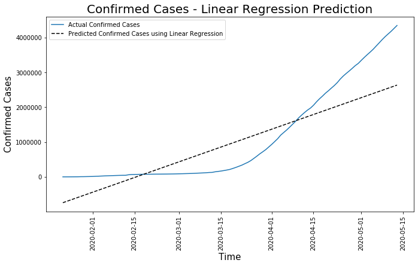

```python
#plot prediction grpah for entire data using trained linear regressor model
plt.figure(figsize=(11,6))
prediction_linreg=lin_reg.predict(np.array(datewise["Days Since"]).reshape(-1,1))
plt.plot(datewise["Confirmed"],label="Actual Confirmed Cases")
plt.plot(datewise.index,prediction_linreg, linestyle='--',label="Predicted Confirmed Cases using Linear Regression",color='black')
plt.xlabel('Time', size=15)
plt.ylabel('Confirmed Cases', size=15)
plt.title("Confirmed Cases - Linear Regression Prediction", size=20)
plt.xticks(rotation=90)
plt.legend();
```

The Linear Regression Model is absolutely falling aprat. As it is clearly visible that the trend of Confirmed Cases in absolutely not Linear

### Logistic Regression Model for Confirmed Cases Prediction

```python
#Logistic Regression
#train_ml=datewise.iloc[:int(datewise.shape[0]*0.90)]
#test_ml=datewise.iloc[int(datewise.shape[0]*0.90):]

model_scores=[]

# Define the model
logist_reg=LogisticRegression(penalty='l2',random_state=0)

#Fit the model
logist_reg.fit(X_train,Y_train)

#Predict the output for
Y_pred_logreg=logist_reg.predict(X_test)

model_scores.append(np.sqrt(mean_squared_error(Y_test,Y_pred_logreg)))

print("Root Mean Square Error for Logistic Regression: ",np.sqrt(mean_squared_error(test_ml["Confirmed"],Y_pred_logreg)))
print("variance or r-squared: ", explained_variance_score(test_ml["Confirmed"], Y_pred_logreg))
```

```
Root Mean Square Error for Logistic Regression:  591530.5343239168
variance or r-squared:  1.1102230246251565e-16
```

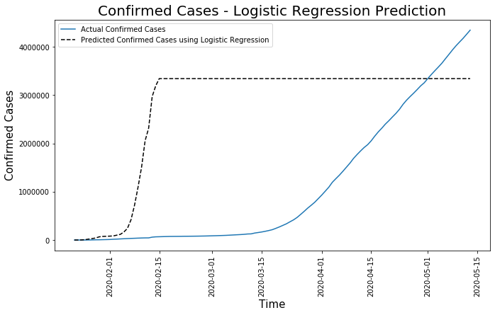

```python
#plot prediction grpah for entire data using trained logistic regressor model
plt.figure(figsize=(11,6))
prediction_logstreg=logist_reg.predict(np.array(datewise["Days Since"]).reshape(-1,1))
plt.plot(datewise["Confirmed"],label="Actual Confirmed Cases")
plt.plot(datewise.index,prediction_logstreg, linestyle='--',label="Predicted Confirmed Cases using Logistic Regression",color='black')
plt.xlabel('Time', size=15)
plt.ylabel('Confirmed Cases', size=15)
plt.title("Confirmed Cases - Logistic Regression Prediction", size=20)
plt.xticks(rotation=90)
plt.legend();
```

### Explanation for using Logistic regression:

- In exponential growth, a population's per capita (per individual) growth rate stays the same regardless of population size, making the population grow faster and faster as it gets larger.
- Exponential growth produces a J-shaped curve, while logistic growth produces an S-shaped curve.

Logisitc equation: I(t) = K / 1 + A exp(−rt)

The Logistic equation above is very general, and we can make more specific forms of it to describe two different kinds of growth models: exponential and logistic

- When the per capita rate of increase (rrr) takes the same positive value regardless of the population size, then we get exponential growth.
- When the per capita rate of increase (rrr) decreases as the population increases towards a maximum limit, then we get logistic growth.

In this model, we pass X as 'Days (nearly 100 days)' and Y as 'continous number of confirmed cases'. While the exponential model predicts the initial growth of a pandemic, it does not account for eventual decay and flattening out of curve. Logistic model on the other hand predicts the eventual decay but failed in initial stages.

#### Reference:

https://www.medrxiv.org/content/10.1101/2020.04.02.20051466v1.full.pdf  
https://www.khanacademy.org/science/biology/ecology/population-growth-and-regulation/a/exponential-logistic-growth

## Random Forest Regressor model for Prediction of Confirmed Cases

A random forest is an ensemble technique and a meta estimator that fits a number of classifying decision trees on various sub-samples of the dataset and uses averaging to improve the predictive accuracy and control over-fitting

```python
#Random Forest Regressor model
#train_ml=datewise.iloc[:int(datewise.shape[0]*0.90)]
#test_ml=datewise.iloc[int(datewise.shape[0]*0.90):]
model_scores=[]

# Define the model
from sklearn.ensemble import RandomForestRegressor
from sklearn.datasets import make_regression
RFR_regr = RandomForestRegressor(n_estimators=100, random_state=0)

X_train =np.array(train_ml["Days Since"]).reshape(-1,1)
Y_train =np.array(train_ml["Confirmed"]).reshape(-1,1)

#Fit the model
RFR_regr.fit(X_train,Y_train)
```

```
RandomForestRegressor(bootstrap=True, criterion='mse', max_depth=None,
                      max_features='auto', max_leaf_nodes=None,
                      min_impurity_decrease=0.0, min_impurity_split=None,
                      min_samples_leaf=1, min_samples_split=2,
                      min_weight_fraction_leaf=0.0, n_estimators=100,
                      n_jobs=None, oob_score=False, random_state=0, verbose=0,
                      warm_start=False)
```

```python
#Predict the output for test dataset
X_test = np.array(test_ml["Days Since"]).reshape(-1,1)
Y_test =np.array(test_ml["Confirmed"]).reshape(-1,1)

RFRregr_predicted = RFR_regr.predict(X_test)
RFRregr_predicted
```

```
array([3297530.41, 3297530.41, 3297530.41, 3297530.41, 3297530.41,
       3297530.41, 3297530.41, 3297530.41, 3297530.41, 3297530.41,
       3297530.41, 3297530.41, 3297530.41])
```

```python
print("Root Mean Square Error for Randome Forest Regression: ", np.sqrt(mean_squared_error(Y_test, RFRregr_predicted)))
print("variance or r-squared: ", explained_variance_score(Y_test, RFRregr_predicted))
```

```
Root Mean Square Error for Randome Forest Regression:  631137.8538337614
variance or r-squared:  1.1102230246251565e-16
```

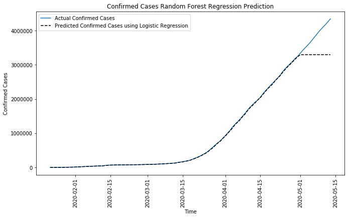

```python
plt.figure(figsize=(11,6))
prediction_RFRreg=RFR_regr.predict(np.array(datewise["Days Since"]).reshape(-1,1))
plt.plot(datewise["Confirmed"],label="Actual Confirmed Cases")
plt.plot(datewise.index,prediction_RFRreg, linestyle='--',label="Predicted Confirmed Cases using Logistic Regression",color='black')
plt.xlabel('Time')
plt.ylabel('Confirmed Cases')
plt.title("Confirmed Cases Random Forest Regression Prediction")
plt.xticks(rotation=90)
plt.legend()
```

## Support Vector Machine Regressor Model for Prediction of Confirmed Cases

- use Support Vector Regression since this is a regression problem.
- most important SVR parameter is Kernel type. It can be #linear, polynomial or gaussian SVR.
- It must be one of ‘linear’, ‘poly’, ‘rbf’, ‘sigmoid’, ‘precomputed’

```python
#Support Vector Machine Regressor Model using polynomial kernel and degree=3
#train_ml=datewise.iloc[:int(datewise.shape[0]*0.90)]
#test_ml=datewise.iloc[int(datewise.shape[0]*0.90):]
model_scores=[]

#Intializing SVR Model
#svr=SVR(C=1,degree=5,kernel='poly',epsilon=0.1)    -- taking long time
#svr=SVR(C=1,degree=5,kernel='rbf',epsilon=0.1)     -- poorly(stright line) predicted
svr=SVR(C=1,degree=3,kernel='poly',epsilon=0.1)

# use GridSearchCV to optimized by cross-validated grid-search over a parameter grid
#parameters = {'kernel': ('linear', 'rbf','poly'), 'C':[1.5, 10],'gamma': [1e-7, 1e-4],'epsilon':[0.1,0.2,0.5,0.3]}
#svr = GridSearchCV(SVR(kernel='rbf', gamma=0.1), parameters)

#Split train and test datasets into X and Y features
X_train = np.array(train_ml["Days Since"]).reshape(-1,1)
Y_train = np.array(train_ml["Confirmed"]).reshape(-1,1)
X_test = np.array(test_ml["Days Since"]).reshape(-1,1)
Y_test = np.array(test_ml["Confirmed"]).reshape(-1,1)

# Scaleup the data
#from sklearn.preprocessing import RobustScaler
#scaling = RobustScaler()
#X_train = scaling.fit_transform(X_train)
#X_test = scaling.fit_transform(X_test)

#Fit SVM model on the training data
svr.fit(X_train,Y_train)

#predict output on validation data
prediction_valid_svm=svr.predict(X_test)

#get meansquare error
#model_scores.append(np.sqrt(mean_squared_error(test_ml["Confirmed"],prediction_valid_svm)))
print("Root Mean Square Error for Support Vectore Machine: ",np.sqrt(mean_squared_error(Y_test,prediction_valid_svm)))
print("variance or r-squared: ", explained_variance_score(Y_test,prediction_valid_svm))
```

```
Root Mean Square Error for Support Vectore Machine:  262332.6491360822
variance or r-squared:  0.8558605324382764
```

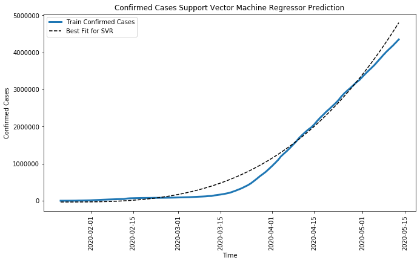

```python
#plot confirmed cases prediction grpah for entire data using trained svm regressor model
plt.figure(figsize=(11,6))
prediction_svm=svr.predict(np.array(datewise["Days Since"]).reshape(-1,1))
plt.plot(datewise["Confirmed"],label="Train Confirmed Cases",linewidth=3)
plt.plot(datewise.index,prediction_svm, linestyle='--',label="Best Fit for SVR",color='black')
plt.xlabel('Time')
plt.ylabel('Confirmed Cases')
plt.title("Confirmed Cases Support Vector Machine Regressor Prediction")
plt.xticks(rotation=90)
plt.legend()
```

```
Forecasted Confirmed cases in next 14 days: [3834822. 3947491. 4062326. 4179349. 4298579. 4420038. 4543747. 4669725.
 4797993. 4928573. 5061484. 5196747. 5334384. 5474414.]
```

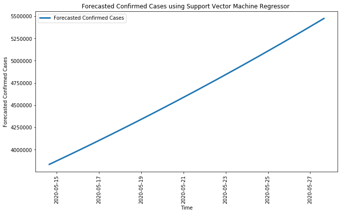

```python
import datetime
today = datetime.datetime.today()
date_list = [today + datetime.timedelta(days=x) for x in range(14)]

plt.figure(figsize=(11,6))
forecast_svm=svr.predict(np.array([[104],[105],[106],[107],[108],[109],[110],[111],[112],[113],[114],[115],[116],[117]]))
print("Forecasted Confirmed cases in next 14 days:", np.round(forecast_svm))

plt.plot(date_list,forecast_svm,label="Forecasted Confirmed Cases",linewidth=3)
#plt.plot(date_list, forecast_svm, linestyle='--',label="Best Fit for SVR",color='black')
plt.xlabel('Time')
plt.ylabel('Forecasted Confirmed Cases')
plt.title("Forecasted Confirmed Cases using Support Vector Machine Regressor ")
plt.xticks(rotation=90)
plt.legend()
```

## Predicting Deaths using SVR

```python
#train_ml=datewise.iloc[:int(datewise.shape[0]*0.90)]
#test_ml=datewise.iloc[int(datewise.shape[0]*0.90):]
model_scores=[]

#Intializing SVR Model
#svr=SVR(C=1,degree=5,kernel='poly',epsilon=0.1)    -- taking long time
#svr=SVR(C=1,degree=5,kernel='rbf',epsilon=0.1)     -- poorly(stright line) predicted
svr=SVR(C=1,degree=3,kernel='poly',epsilon=0.1)

# use GridSearchCV to optimized by cross-validated grid-search over a parameter grid
#parameters = {'kernel': ('linear', 'rbf','poly'), 'C':[1.5, 10],'gamma': [1e-7, 1e-4],'epsilon':[0.1,0.2,0.5,0.3]}
#svr = GridSearchCV(SVR(kernel='rbf', gamma=0.1), parameters)

#Split train and test datasets
X_train = np.array(train_ml["Days Since"]).reshape(-1,1)
Y_train = np.array(train_ml["Deaths"]).reshape(-1,1)
X_test = np.array(test_ml["Days Since"]).reshape(-1,1)
Y_test = np.array(test_ml["Deaths"]).reshape(-1,1)

# Scaleup the data
#from sklearn.preprocessing import RobustScaler
#scaling = RobustScaler()
#X_train = scaling.fit_transform(X_train)
#X_test = scaling.fit_transform(X_test)

#Fit SVM model on the training data
svr.fit(X_train,Y_train)

#predict output on validation data
prediction_valid_svm=svr.predict(X_test)

#get meansquare error
#model_scores.append(np.sqrt(mean_squared_error(Y_test,prediction_valid_svm)))
print("Root Mean Square Error for Support Vectore Machine: ",np.sqrt(mean_squared_error(Y_test,prediction_valid_svm)))
print("variance or r-squared: ", explained_variance_score(Y_test,prediction_valid_svm))
```

```
Root Mean Square Error for Support Vectore Machine:  12063.979935113119
variance or r-squared:  0.7332401668458643
```

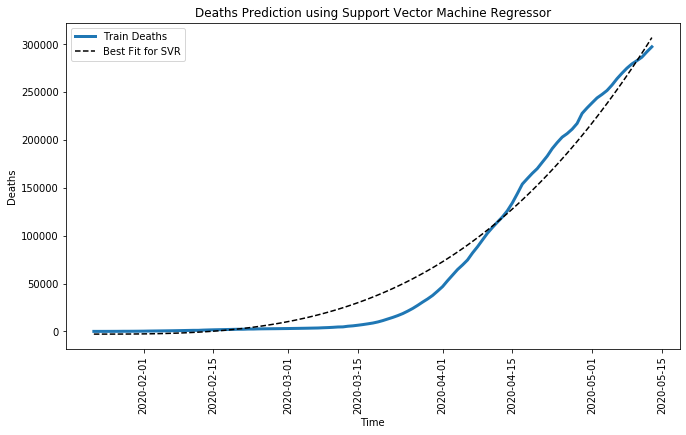

```python
#plot death prediction grpah for entire data using trained svm regressor model
plt.figure(figsize=(11,6))
prediction_svm=svr.predict(np.array(datewise["Days Since"]).reshape(-1,1))
plt.plot(datewise["Deaths"],label="Train Deaths",linewidth=3)
plt.plot(datewise.index,prediction_svm, linestyle='--',label="Best Fit for SVR",color='black')
plt.xlabel('Time')
plt.ylabel('Deaths')
plt.title("Deaths Prediction using Support Vector Machine Regressor")
plt.xticks(rotation=90)
plt.legend()
```

```
Forecasted Confirmed cases in next 14 days: [245087. 252307. 259666. 267165. 274805. 282589. 290516. 298589. 306809.
 315177. 323694. 332362. 341182. 350155.]
```

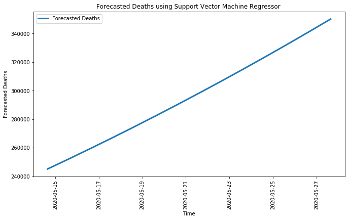

```python
import datetime
today = datetime.datetime.today()
date_list = [today + datetime.timedelta(days=x) for x in range(14)]

plt.figure(figsize=(11,6))
forecast_svm=svr.predict(np.array([[104],[105],[106],[107],[108],[109],[110],[111],[112],[113],[114],[115],[116],[117]]))
print("Forecasted Confirmed cases in next 14 days:", np.round(forecast_svm))

plt.plot(date_list,forecast_svm,label="Forecasted Deaths",linewidth=3)
#plt.plot(date_list, forecast_svm, linestyle='--',label="Best Fit for SVR",color='black')
plt.xlabel('Time')
plt.ylabel('Forecasted Deaths')
plt.title("Forecasted Deaths using Support Vector Machine Regressor ")
plt.xticks(rotation=90)
plt.legend()
```

## Gaussian Process Regressor (RBF kernel) model for prediction of confirmed cases: 1D

```python
from sklearn.datasets import make_friedman2
from sklearn.gaussian_process import GaussianProcessRegressor
from sklearn.gaussian_process.kernels import DotProduct, WhiteKernel,ConstantKernel, RBF

X_train = np.array(train_ml["Days Since"]).reshape(-1,1)
Y_train = np.array(train_ml["Confirmed"]).reshape(-1,1)
X_test = np.array(test_ml["Days Since"]).reshape(-1,1)
Y_test = np.array(test_ml["Confirmed"]).reshape(-1,1)

#kernel = ConstantKernel(1.0) * RBF(length_scale=1.0)
kernel = ConstantKernel(1.0, (1e-3, 1e3)) * RBF(1, (1e-2, 1e2))
gpr = GaussianProcessRegressor(kernel=kernel, alpha=1e-10)

#Fit SVM model on the training data
gpr.fit(X_train,Y_train)
print("gpr score: ", gpr.score(X_train,Y_train))

#predict output on validation data
predict_ytest_gpr = gpr.predict(X_test)

print("Root Mean Square Error for Support Vectore Machine: ",np.sqrt(mean_squared_error(Y_test,predict_ytest_gpr)))
print("variance or r-squared: ", explained_variance_score(Y_test,predict_ytest_gpr))
```

```
gpr score:  1.0
Root Mean Square Error for Support Vectore Machine:  3415865.89764121
variance or r-squared:  -20.49470882423981
```

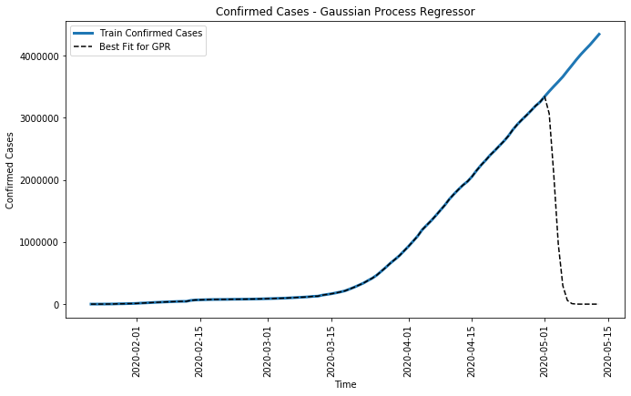

```python
#plot confirmed cases prediction grpah for entire data using trained gpc regressor model
plt.figure(figsize=(11,6))
prediction_gpr=gpr.predict(np.array(datewise["Days Since"]).reshape(-1,1))
plt.plot(datewise["Confirmed"],label="Train Confirmed Cases",linewidth=3)
plt.plot(datewise.index,prediction_gpr, linestyle='--',label="Best Fit for GPR",color='black')
plt.xlabel('Time')
plt.ylabel('Confirmed Cases')
plt.title("Confirmed Cases - Gaussian Process Regressor")
plt.xticks(rotation=90)
plt.legend()
```

# Conclusion:

# Reference:

Kaggle dataset (14-May-2020)- https://www.kaggle.com/sudalairajkumar/novel-corona-virus-2019-dataset  
Kaggle Kernel (30-Mar-2020)- https://www.kaggle.com/neelkudu28/covid-19-visualizations-predictions-forecasting